# Part I - Exploration of the Carrier On-Time Performance Dataset from Bureau of Transportation

## Introduction

This document explores a dataset from Bureau of Transportation containing 2,000,000 flights in the United States, including carriers, arrival and departure delays, and reasons for delays from 1987 to 2020.

## Preliminary Wrangling

```python
# import all packages and set plots to be embedded inline
import tarfile
import numpy as np
import pandas as pd
import matplotlib.pyplot as plt
import seaborn as sns
from scipy.stats import lognorm
from sklearn.metrics import r2_score
```

```python
# extract files from archive and load csv
with tarfile.open("./data/airline_2m.tar.gz", "r:gz") as t:
    for filename in t.getnames():
        try:
            f = t.extractfile(filename)
            print(f'Extracted {filename}')
        except :
            print( 'ERROR: Did not find %s in tar archive' % filename)
        if filename[-4:]=='.csv':
            try:
                flights_df = pd.read_csv(f, low_memory=False, encoding='latin1')
                print(f"Successfully loaded {filename} with shape: {flights_df.shape}")
            except Exception as e:
                print(f"Error reading CSV: {type(e).__name__} - {e}")
            flights_df.head()
        else:
            print(f'File extracted is not a csv: {filename}')
```

```
Extracted airline_2m.csv
Successfully loaded airline_2m.csv with shape: (2000000, 109)
```

```python
# print information about the dataframe
flights_df.info()
```

```
<class 'pandas.core.frame.DataFrame'>
RangeIndex: 2000000 entries, 0 to 1999999
Columns: 109 entries, Year to Div5TailNum
dtypes: float64(72), int64(18), object(19)
memory usage: 1.6+ GB
```

```python
print(f"Flights dates go from {flights_df['Year'].min()} to {flights_df['Year'].max()}")
```

```
Flights dates go from 1987 to 2020
```

The dataset is too big for the compute to handle efficiently. We will focus on the last 20 years of data (2000 to 2020)

```python
flights_df = flights_df[flights_df['Year']>=2000]
```

Are there any duplicates?

```python
flights_df.duplicated().any()
```

```
False
```

The dataset is exempt of duplicates.

What are the features available and their data types?

```python
# set option to display all rows
pd.set_option('display.max_rows', None)
print(flights_df.dtypes)
pd.reset_option('display.max_rows')
```

```
Year                                 int64
Quarter                              int64
Month                                int64
DayofMonth                           int64
DayOfWeek                            int64
FlightDate                          object
Reporting_Airline                   object
DOT_ID_Reporting_Airline             int64
IATA_CODE_Reporting_Airline         object
Tail_Number                         object
Flight_Number_Reporting_Airline      int64
OriginAirportID                      int64
OriginAirportSeqID                   int64
OriginCityMarketID                   int64
Origin                              object
OriginCityName                      object
OriginState                         object
OriginStateFips                    float64
OriginStateName                     object
OriginWac                            int64
DestAirportID                        int64
DestAirportSeqID                     int64
DestCityMarketID                     int64
Dest                                object
DestCityName                        object
DestState                           object
DestStateFips                      float64
DestStateName                       object
DestWac                              int64
CRSDepTime                           int64
DepTime                            float64
DepDelay                           float64
DepDelayMinutes                    float64
DepDel15                           float64
DepartureDelayGroups               float64
DepTimeBlk                          object
TaxiOut                            float64
WheelsOff                          float64
WheelsOn                           float64
TaxiIn                             float64
```

[output cut: 55 more lines]

```
Div4AirportSeqID                   float64
Div4WheelsOn                       float64
Div4TotalGTime                     float64
Div4LongestGTime                   float64
Div4WheelsOff                      float64
Div4TailNum                        float64
Div5Airport                        float64
Div5AirportID                      float64
Div5AirportSeqID                   float64
Div5WheelsOn                       float64
Div5TotalGTime                     float64
Div5LongestGTime                   float64
Div5WheelsOff                      float64
Div5TailNum                        float64
dtype: object
```

The FlightDate is set as a string, let's convert it to a datetime

```python
flights_df['FlightDate'] = flights_df['FlightDate'].astype('datetime64[ns]')
```

Are there any null values?

```python
missing_counts = flights_df.isnull().sum()
pd.set_option('display.max_rows', None)
print(missing_counts[missing_counts > 0])
pd.reset_option('display.max_rows')
```

```
Tail_Number                8060
DepTime                   25213
DepDelay                  25276
DepDelayMinutes           25276
DepDel15                  25276
DepartureDelayGroups      25276
TaxiOut                   25564
WheelsOff                 25584
WheelsOn                  27248
TaxiIn                    27178
ArrTime                   27178
ArrDelay                  28705
ArrDelayMinutes           28705
ArrDel15                  28705
ArrivalDelayGroups        28705
CancellationCode        1318790
CRSElapsedTime               28
ActualElapsedTime         28679
AirTime                   28680
CarrierDelay            1117207
WeatherDelay            1117207
NASDelay                1117207
SecurityDelay           1117207
LateAircraftDelay       1117207
FirstDepTime            1334556
TotalAddGTime           1334556
LongestAddGTime         1334556
DivAirportLandings       592896
DivReachedDest          1337235
DivActualElapsedTime    1337509
DivArrDelay             1337509
DivDistance             1337235
Div1Airport             1337129
Div1AirportID           1337129
Div1AirportSeqID        1337129
Div1WheelsOn            1337129
Div1TotalGTime          1337129
Div1LongestGTime        1337129
Div1WheelsOff           1337498
Div1TailNum             1337496
```

[output cut: 18 more lines]

```
Div4AirportSeqID        1339010
Div4WheelsOn            1339010
Div4TotalGTime          1339010
Div4LongestGTime        1339010
Div4WheelsOff           1339010
Div4TailNum             1339010
Div5Airport             1339010
Div5AirportID           1339010
Div5AirportSeqID        1339010
Div5WheelsOn            1339010
Div5TotalGTime          1339010
Div5LongestGTime        1339010
Div5WheelsOff           1339010
Div5TailNum             1339010
dtype: int64
```

We have a lot of them!

The columns starting with div are related to diverted flights, so it makes sense to miss values there. Same for the cancellation reason.

The columns stating the time each delay cause triggered also have a lot of null, which makes sense if the flights are on time.

### What is the structure of your dataset?

The data consists of 109 features on 2,000,000 flights. Most of the data are numeric.

### What is/are the main feature(s) of interest in your dataset?

There is a lot of features in this dataset. The main interest of the dataset is to analyse the delays that can happen when flying.

Given the information available to us, we can investigate where and in which circunstances these delays are most likely to happen.

Thus the ArrDelay and DepDelay are the main features we are interested in.

### What features in the dataset do you think will help support your investigation into your feature(s) of interest?

DOT_ID_Reporting_Airline, ArrDelay, CRSElapsedTime, ActualElapsedTime, AirTime, Distance, CarrierDelay, WeatherDelay, NASDelay, SecurityDelay, LateAircraftDelay might be the most interesting features for our analysis.

These will let us provide a complete operational view of what drives flight delays and how severely they impact performance.

## Functions used in the exploration

```python
# function to add title and axes labels
def generate_title_and_axes(title, x_axis, y_axis):
    plt.title(title)
    plt.xlabel(x_axis)
    plt.ylabel(y_axis)
```

```python
# function to generate a countplot with tilted axis labels
def countplot(df,x):
    sns.countplot(data=df, x=x)
    plt.xticks(rotation=45);
```

```python
# function to generate a histogram with log-normal fit
def lognorm_comparison(col, xmin, xmax, tick_step, ymax=None):
    data = flights_df_clean[col].dropna()
    min_val = data.min()

    s, loc, scale = lognorm.fit(data, floc=min_val-1)

    x = np.linspace(xmin, xmax, 500)
    p = lognorm.pdf(x, s, loc, scale)

    sns.histplot(data, stat="density", kde=True)
    plt.plot(x, p, 'r--', linewidth=2, label=f'Log-Normal Fit')

    plt.xlim(xmin, xmax);
    if ymax:
        plt.ylim(0,ymax);
    plt.xticks(range(xmin, xmax+1, tick_step));
    plt.legend();
#     plt.show()

    return s, loc, scale
```

```python
# function to generate the Q-Q graph of a log-normal fit
def lognorm_qq_graph(col, s, loc, scale):
    n_points = flights_df_clean.shape[0]
    qs = (np.arange(n_points) - .5) / n_points
    expected_vals = lognorm.ppf(qs, s, loc, scale)

    plt.scatter(expected_vals, flights_df_clean[col].sort_values())
    plt.plot([-500,500],[-500,500],'--', color = 'black')
    plt.axis('equal')
    generate_title_and_axes(f'{col} Q-Q graph for log-normal fitting', 'Expected Values', 'Observed Values')
```

```python
# function to calculate R2 for a linear regression
def calculate_r2(model, x, y):
    predict = np.poly1d(model)
    return r2_score(y, predict(x))
```

```python
# function to convert categories into intervals
def calculate_interval_ticks_labels(min, max, step):
    boundaries = np.arange(min, max, step)
    tick_labels = [f"<{boundaries[0]}"]
    for start, end in zip(boundaries[:-1], boundaries[1:]):
        tick_labels.append(f"[{start}, {end}[")
    tick_labels.append(f">{boundaries[-1]}")
    return tick_labels
```

## Univariate Exploration

First, let's have a look at the distribution of arrival delays

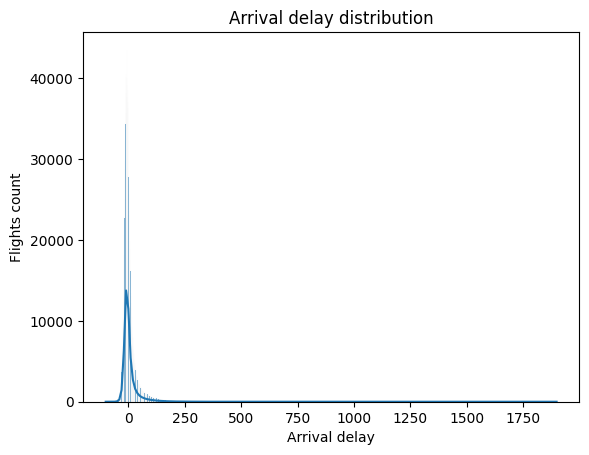

```python
sns.histplot(flights_df['ArrDelay'], kde=True);
generate_title_and_axes('Arrival delay distribution', 'Arrival delay', 'Flights count')
```

Most of the flights seem to arrive early or a few minutes late.

Let's change the scale of the graph to better estimate the delays.

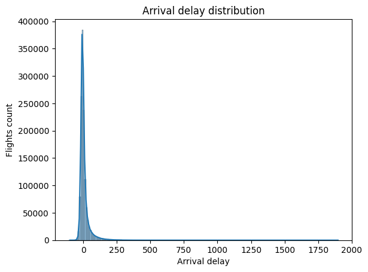

```python
# change the bins to have a better look at the distribution
bins=np.arange(flights_df['ArrDelay'].min()-10, flights_df['ArrDelay'].max()+10, 10)

# plot
sns.histplot(flights_df['ArrDelay'], bins=bins, kde=True);
generate_title_and_axes('Arrival delay distribution', 'Arrival delay', 'Flights count')
```

We seem to have some outliers or a long tail

Let's zoom on the main area of data

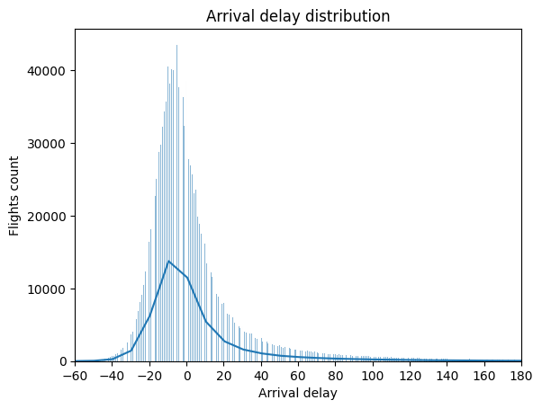

```python
sns.histplot(flights_df['ArrDelay'], kde=True);
plt.xlim(-60, 180);
plt.xticks(range(-60, 181, 20));
generate_title_and_axes('Arrival delay distribution', 'Arrival delay', 'Flights count')
```

The delay at arrival looks like a log-normal distribution distribution with its long right tail. We'll verify this assumption in the next section.

Let's plot the distribution by arrival delay groups for more clarity

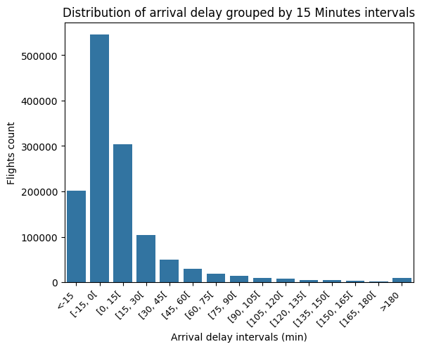

```python
# plot the distribution of arrival delay grouped by 15-Minute intervals
countplot(flights_df,'ArrivalDelayGroups')

# convert groups to intervals
tick_labels = calculate_interval_ticks_labels(-15, 195, 15)

plt.xticks(
            ticks=np.arange(len(tick_labels)),
            labels=tick_labels,
            rotation=45,
            ha='right',
            fontsize=9
            )

generate_title_and_axes('Distribution of arrival delay grouped by 15 Minutes intervals', 'Arrival delay intervals (min)', 'Flights count')
```

It is clear that a big proportion of the flights arrive ahead of time or on-time

Let's have a look at the departure delay to see if it looks similar.

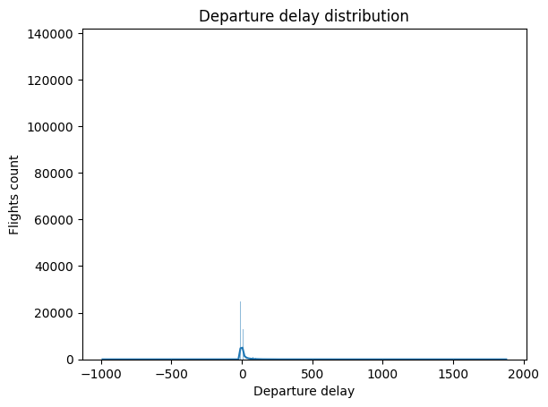

```python
sns.histplot(flights_df['DepDelay'], kde=True);
generate_title_and_axes('Departure delay distribution', 'Departure delay', 'Flights count')
```

Let's zoom in

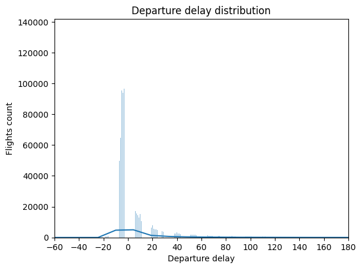

```python
sns.histplot(flights_df['DepDelay'], kde=True);
plt.xlim(-60, 180);
plt.xticks(range(-60, 181, 20));
generate_title_and_axes('Departure delay distribution', 'Departure delay', 'Flights count')
```

At first sight the distribution appears more clustered but we have a similar peak and tail.

Let's print the other graphs and see how close they are

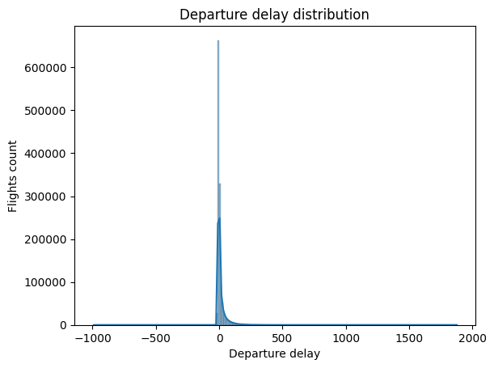

```python
# change the bins to have a better look at the distribution
bins=np.arange(flights_df['DepDelay'].min()-10, flights_df['DepDelay'].max()+10, 10)

# plot
sns.histplot(flights_df['DepDelay'], bins=bins, kde=True);
generate_title_and_axes('Departure delay distribution', 'Departure delay', 'Flights count')
```

There is a high concentration of data point between 0 and 200. Let's zoom in

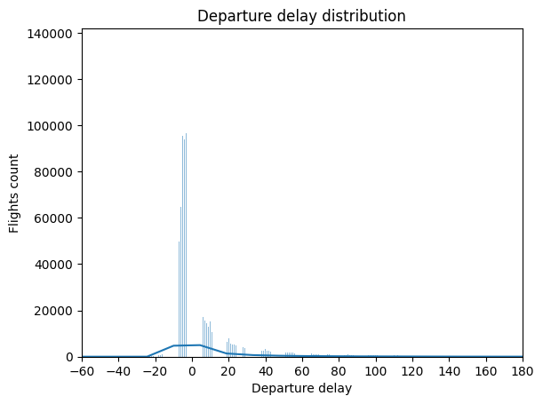

```python
sns.histplot(flights_df['DepDelay'], kde=True);
plt.xlim(-60, 180);
plt.xticks(range(-60, 181, 20));
generate_title_and_axes('Departure delay distribution', 'Departure delay', 'Flights count')
```

Here is the conclusion we can takeout of these graphs:

- More flights arrive early than leave early
- Departure delays are less continuous than the arrival ones. We can see sevral groups on the graph
- Departure and arrival delays both have a right tail

Looking at the distributions, we can drop any data where the flight is more than 60min in advance. It clearly is outliers

```python
flights_df_clean = flights_df[(flights_df['DepDelay'] > -60) & (flights_df['ArrDelay'] > -60)].copy()
```

Let's have a look at the flights delayed more than 15min over the years

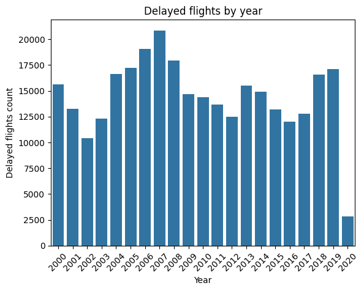

```python
# filter the dataframe
flights_delayed15_df=flights_df_clean[(flights_df_clean['DepDel15']==1) | (flights_df_clean['ArrDel15']==1)]

# plot
countplot(flights_delayed15_df,'Year')
generate_title_and_axes('Delayed flights by year', 'Year', 'Delayed flights count')
```

There is no trend standing out over the years.

Is the distance impacting the arrival delay? Let's see the distribution we have in the Distance feature

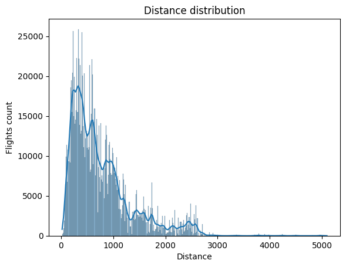

```python
sns.histplot(flights_df_clean['Distance'], kde=True);
generate_title_and_axes('Distance distribution', 'Distance', 'Flights count')
```

Let's group them by DistanceGroup

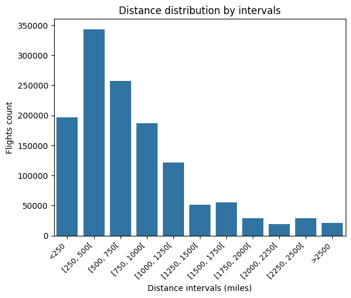

```python
countplot(flights_df_clean,'DistanceGroup')

# convert group to intervals
tick_labels = calculate_interval_ticks_labels(250, (flights_df_clean['DistanceGroup'].max())*250, 250)

plt.xticks(
            ticks=np.arange(len(tick_labels)),
            labels=tick_labels,
            rotation=45,
            ha='right',
            fontsize=9
            )
generate_title_and_axes('Distance distribution by intervals', 'Distance intervals (miles)', 'Flights count')
```

We have mainly short and medium haul in this dataset. Which means our analysis will be limited to these distances.

What about the delay causes that are mentionned in the features? How do they rank to each other?

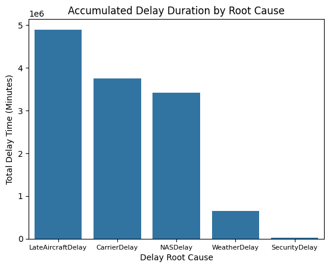

```python
# Calculate total sum of delay for each root cause
delay_cols = ['CarrierDelay', 'WeatherDelay', 'NASDelay', 'SecurityDelay', 'LateAircraftDelay']

total_minutes = flights_df[delay_cols].sum().reset_index()
total_minutes.columns = ['DelayType', 'TotalMinutes']
total_minutes = total_minutes.sort_values(by='TotalMinutes', ascending=False)

# plot
sns.barplot(
            data=total_minutes,
            x='DelayType',
            y='TotalMinutes'
            )

generate_title_and_axes(
                        "Accumulated Delay Duration by Root Cause",
                        "Delay Root Cause",
                        "Total Delay Time (Minutes)"
                        )

plt.xticks(fontsize=8)
plt.show()
```

A late aircraft causes the more delays in terms of time. However a late aircraft means there has been a consequence of at least one of the other causes at the origin. So we could consider Carrier delays, which comes second, as the main reason for delays.

### Discuss the distribution(s) of your variable(s) of interest. Were there any unusual points? Did you need to perform any transformations?

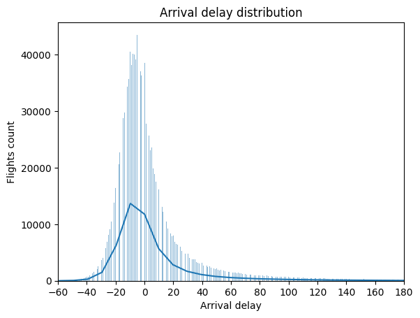

```python
sns.histplot(flights_df_clean['ArrDelay'], kde=True);
plt.xlim(-60, 180);
plt.xticks(range(-60, 181, 20));
generate_title_and_axes('Arrival delay distribution', 'Arrival delay', 'Flights count')
```

The delay at arrival looks like a log-normal distribution with its long right tail.

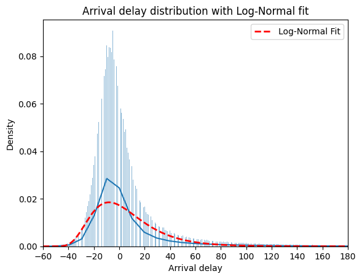

```python
s, loc, scale = lognorm_comparison('ArrDelay', -60, 180, 20)
generate_title_and_axes('Arrival delay distribution with Log-Normal fit', 'Arrival delay', 'Density')
```

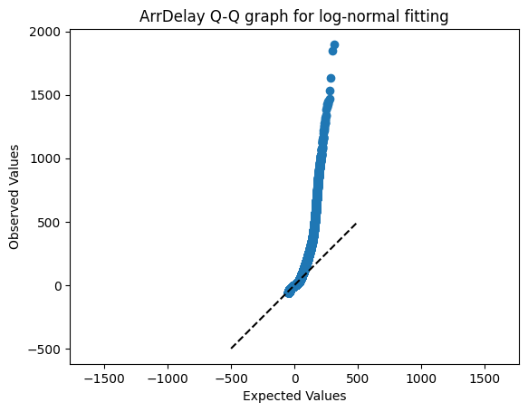

```python
# print Q-Q plot to confirm the log-normal fit
lognorm_qq_graph('ArrDelay', s, loc, scale)
```

Looking at the Q-Q plot, the data severely departs from the diagonal reference line: flight arrival delays do not follow a theoretical log-normal distribution.

Flight delays will be better described as a heavy-tailed empirical distribution rather than a simple log-normal curve.

What about departure delays?

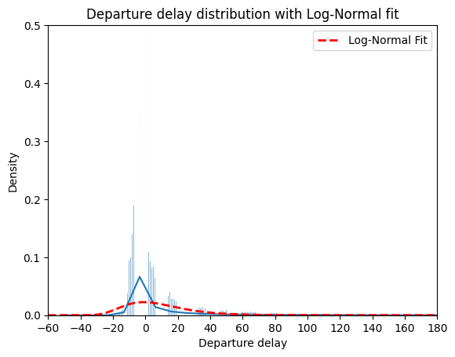

```python
s, loc, scale = lognorm_comparison('DepDelay', -60, 180, 20, 0.5)
generate_title_and_axes('Departure delay distribution with Log-Normal fit', 'Departure delay', 'Density')
```

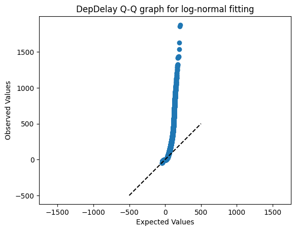

```python
lognorm_qq_graph('DepDelay', s, loc, scale)
```

Once again the Q-Q plot shows a large discrepency between the data and the reference line. Flight departure delays do not follow a theoretical log-normal distribution.

Flight delays will also be better described as a heavy-tailed empirical distribution rather than a simple log-normal curve.

### Of the features you investigated, were there any unusual distributions? Did you perform any operations on the data to tidy, adjust, or change the form of the data? If so, why did you do this?

We filtered the data to keep only the last 20 years of data to ease the load on the compute that was not able to process such an amount of data for some graphs. The analysis will then focus on the most recent years, which would be the most important data in case we would like to predict any future delays.

## Bivariate Exploration

Is there a clear relationship between late departure and late arrival?

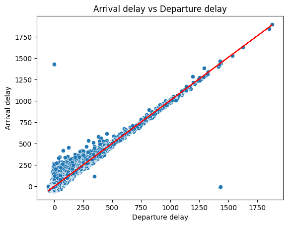

```python
sns.scatterplot(data=flights_df_clean, x='DepDelay', y='ArrDelay');
# Add trend
model = np.polyfit(flights_df_clean['DepDelay'].astype(np.float32), flights_df_clean['ArrDelay'].astype(np.float32), 1)
plt.plot(flights_df_clean['DepDelay'].astype(np.float32), model[0] * flights_df_clean['DepDelay'].astype(np.float32) + model[1], color="red")
generate_title_and_axes('Arrival delay vs Departure delay', 'Departure delay', 'Arrival delay')
```

```python
calculate_r2(model, flights_df_clean['DepDelay'], flights_df_clean['ArrDelay'])
```

```
0.8729530857177679
```

$R^{2}$ tells us that 87.3% of the variance in the arrival delay is explained by the model. Which means the linear model represneted by y = model[0] x + model[1] is a good representation of the relationship between departure delay and arrival delay

```python
print(f'The model has the following equation: y = {model[0]}x + {model[1]}')
```

```
The model has the following equation: y = 1.0085281144590827x + -3.2361786504421612
```

Considering the existence of this model, we will focus on one of the variable of interests: ArrDelay

Is there a relationship between the Airline we are flying and the delay at arrival? Let's see for each airline the proportion of flights in each delay group using a stacked bar chart.

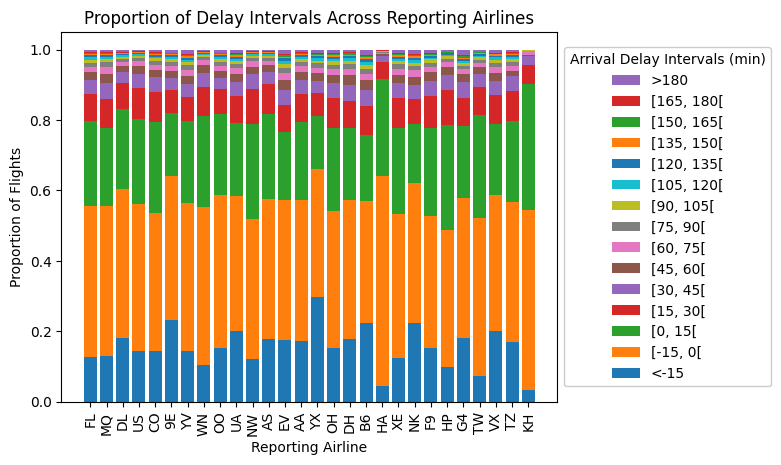

```python
# prepare variables neeeded for the loop on the delay groups
airlines = flights_df_clean['Reporting_Airline'].unique()
airlines_counts = flights_df_clean['Reporting_Airline'].value_counts()
arrdelaysgrp_ordered = sorted(flights_df_clean['ArrivalDelayGroups'].unique())

baselines = np.zeros(len(airlines))
artists = []

for i in range(len(arrdelaysgrp_ordered)):
    # calculate the proportion of the category
    arrdelaygrp = arrdelaysgrp_ordered[i]
    inner_counts = flights_df_clean[flights_df_clean['ArrivalDelayGroups'] == arrdelaygrp]['Reporting_Airline'].value_counts()
    inner_props = inner_counts / airlines_counts
    # create the associated bars
    bars = plt.bar(
                    x = np.arange(len(airlines)),
                    height = inner_props[airlines],
                    bottom = baselines
                    )
    artists.append(bars)
    baselines += inner_props[airlines]

plt.xticks(np.arange(len(airlines)), airlines, rotation = 90)

# create the legend with the intervals instead of the category labels
interval_labels = calculate_interval_ticks_labels(-15, 195, 15)
legend_labels = [interval_labels[int(i) + 2] if -2 <= i <= 12 else str(i) for i in arrdelaysgrp_ordered]
plt.legend(reversed(artists), reversed(legend_labels), title= 'Arrival Delay Intervals (min)', framealpha = 1, bbox_to_anchor = (1, 0.5), loc = 6);

generate_title_and_axes(
                        "Proportion of Delay Intervals Across Reporting Airlines",
                        "Reporting Airline",
                        "Proportion of Flights"
                        )
```

We can see that 2 airlines (HA - Hawaiian Airlines and KH - Aloha Air Cargo) stand out by being mostly in advance or on time compared to the other airlines.

We could think that some airlines are flying longer distance. Let's see how the distance is dispatched among the delays

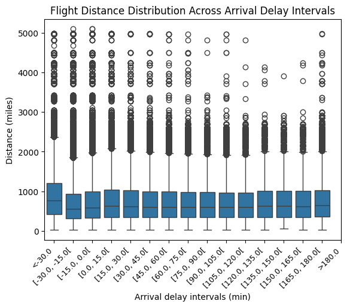

```python
flights_df_clean_sorted = flights_df_clean.sort_values(by='ArrivalDelayGroups')
ax1 = sns.boxplot(data=flights_df_clean_sorted, x='ArrivalDelayGroups', y='Distance', color='tab:blue')

# update group index by intervals
tick_labels = calculate_interval_ticks_labels(-30, (flights_df_clean_sorted['ArrivalDelayGroups'].max()+1)*15, 15)
plt.xticks(
            ticks=np.arange(len(tick_labels)),
            labels=tick_labels,
            rotation=45,
            ha='right',
            fontsize=9
            )

generate_title_and_axes(
                        "Flight Distance Distribution Across Arrival Delay Intervals",
                        "Arrival delay intervals (min)",
                        "Distance (miles)"
                        )
```

### Talk about some of the relationships you observed in this part of the investigation. How did the feature(s) of interest vary with other features in the dataset?

- We notcied that the departure delay and arrival delay have a linear model linking them together, so we excluded the departure delay from the investigation.
- We also showed that 2 airlines stand out by being more on time/in advance than others.
- Finally, we discovered that the most in advance flights tend to be flying on a slighly longer distance.

### Did you observe any interesting relationships between the other features (not the main feature(s) of interest)?

We did observe the relationship between ArrivalDelayGroup and the Distance but ArrivalDelayGroup is based on the value of our main feature of interest.

## Multivariate Exploration

We earlier noticed that the Late Aircraft and Carrier delay seem to be the root causes that trigger the most accumulated delays. We also saw that some airlines are more on time than others and that the on time flights seem to be a bit longer.

Let's explore a bit deeper the different root causes to see the impact of each of them by airline and distance.

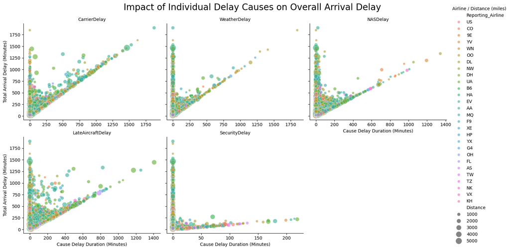

```python
# filter to keep only the flights which arrived late
flights_delayed_df = flights_df_clean[flights_df_clean['ArrDelay'] > 0].copy()

# let's add a column for delay type
delay_causes = ['CarrierDelay', 'WeatherDelay', 'NASDelay', 'LateAircraftDelay', 'SecurityDelay']
melted_flights_delayed_df = flights_delayed_df.melt(
                                                    id_vars=['ArrDelay', 'Reporting_Airline', 'Distance'],
                                                    value_vars=delay_causes,
                                                    var_name='DelayType',
                                                    value_name='DelayMinutes'
                                                    )

g = sns.FacetGrid(melted_flights_delayed_df, col='DelayType', col_wrap=3, height=4, aspect=1.2, sharex=False, sharey=True)

g.map_dataframe(sns.scatterplot, x='DelayMinutes', y='ArrDelay', hue='Reporting_Airline', size='Distance', sizes=(20, 200), alpha=0.6)

g.set_axis_labels("Cause Delay Duration (Minutes)", "Total Arrival Delay (Minutes)")
g.set_titles(col_template="{col_name}")
g.add_legend(title="Airline / Distance (miles)")
plt.subplots_adjust(top=0.9)
g.fig.suptitle("Impact of Individual Delay Causes on Overall Arrival Delay", fontsize=20)

plt.show()
```

Looking at the graphs we can notice:

- a diagonal x=y in most graphs that corresponds to the flights whose delay was entirely explained by the primary cause of the graph.
- In the case of the security delays, a lot of the points are below the diagonal, meaning the delay got recovered.
- a vertical line at 0 in all graphs that corresponds to the flights whose delay was entirely explained by the causes other than the primary one of the graph.
- points in between these 2 lines where multiple factor contributed to the delay.
- Security delay is the reason occuring less often.
- The reporting airline is difficult to analyse on this graph as there is so many of them that the colors get mixed up
- We can see points of different sizes all over each graph, which means long distance flights do not seem to be more delayed than others.

The scatter graphs do not enable us to properly see the frequency of delays for each root cause, let's investigate it.

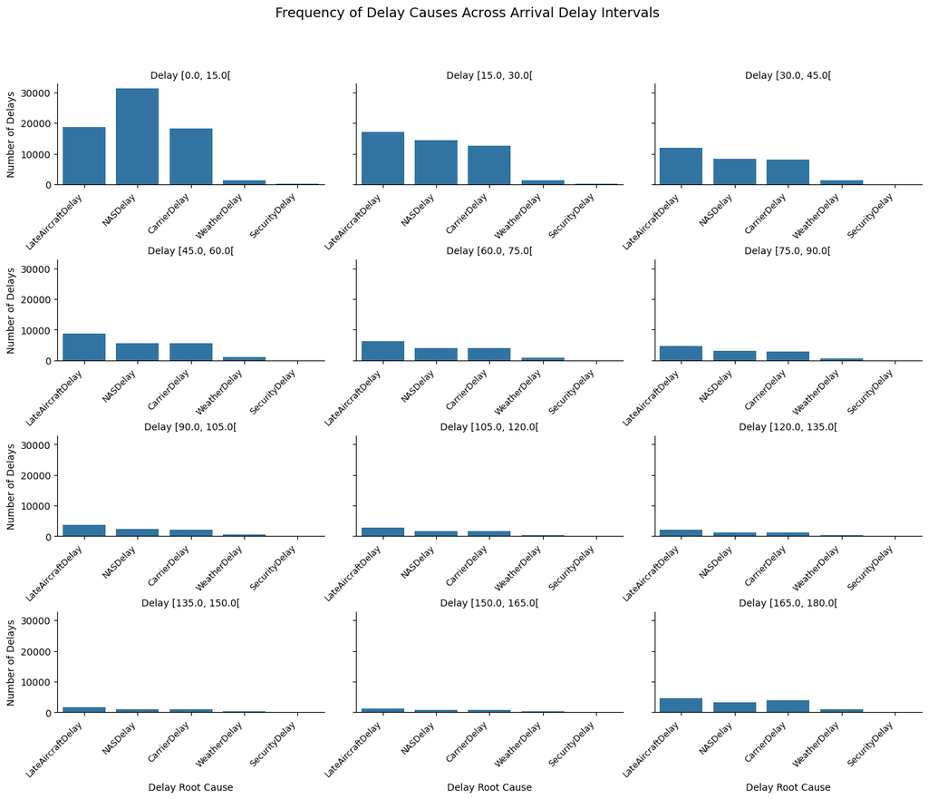

```python
# let's add a column for delay type
delay_cols = ['CarrierDelay', 'WeatherDelay', 'NASDelay', 'SecurityDelay', 'LateAircraftDelay']
df_delays = flights_df[['ArrivalDelayGroups'] + delay_cols].melt(
                                                                id_vars=['ArrivalDelayGroups'],
                                                                value_vars=delay_cols,
                                                                var_name='DelayType',
                                                                value_name='DelayMinutes'
                                                                )

# we keep only the flights that are late
df_delays = df_delays[df_delays['DelayMinutes'] >= 15].copy()

# calculate the delay intervals
interval_labels = calculate_interval_ticks_labels(-30, (df_delays['ArrivalDelayGroups'].max()+1)*15, 15)
df_delays['DelayInterval'] = df_delays['ArrivalDelayGroups'].apply(lambda g: interval_labels[int(g) + 2] if -2 <= g <= 12 else str(g))

# define the order we will plot each category and interval
delay_order = df_delays['DelayType'].value_counts().index
unique_groups = sorted(df_delays['ArrivalDelayGroups'].unique())
interval_order = [interval_labels[int(i) + 2] for i in unique_groups if -2 <= i <= 12]

# plot
g = sns.FacetGrid(
                data=df_delays,
                col='DelayInterval',
                col_order=interval_order,
                col_wrap=3,
                height=3.5,
                aspect=1.3,
                sharex=False
                )

g.map_dataframe(sns.countplot, x='DelayType', order=delay_order, color='tab:blue')

g.set_xticklabels(labels=delay_order, rotation=45, ha='right', fontsize=9)
g.set_titles(col_template="Delay {col_name}")
g.set_axis_labels("Delay Root Cause", "Number of Delays")

plt.subplots_adjust(hspace=0.75, bottom=0.25, top=0.9)
g.fig.suptitle("Frequency of Delay Causes Across Arrival Delay Intervals", fontsize=14, y=0.98)

plt.show()
```

When the delay increases, Late aircraft becomes the dominant cause.

In all the delay groups, Late Aircraft, NAS and Carrier are the main delay drivers.

Now that we have looked at the cause of the delays and we have found a linear relationship between departure delays and arrival delays, let's look at the flight performance. How much do they recover in air?

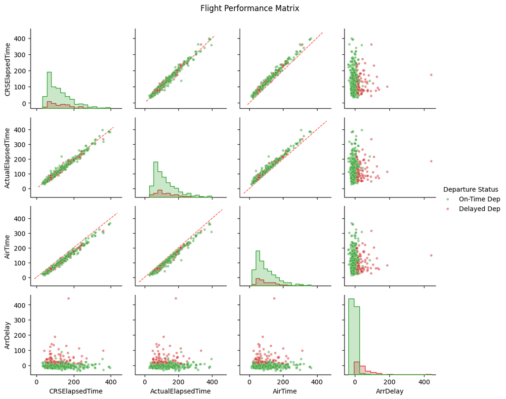

```python
# filter dataframe on the columns needed
plot_vars = ['CRSElapsedTime', 'ActualElapsedTime', 'AirTime', 'ArrDelay']
cols_needed = plot_vars + ['DepDel15', 'ArrDel15']
subset_df = flights_df_clean[cols_needed].dropna().copy()

# Sample 500 rows for memory
sample_df = subset_df.sample(n=min(500, len(subset_df)), random_state=42).copy()

sample_df['Departure Status'] = sample_df['DepDel15'].map({0: 'On-Time Dep', 1: 'Delayed Dep'})

g = sns.PairGrid(
                sample_df,
                vars=plot_vars,
                hue='Departure Status',
                palette={'On-Time Dep': 'tab:green', 'Delayed Dep': 'tab:red'},
                height=2.2,
                aspect=1.1
                )

g.map_offdiag(sns.scatterplot, alpha=0.5, s=15)
g.map_diag(sns.histplot, bins=15, element='step')

# add diagonal on graphs that seem to follow it
# row 1 col 0
ax_10 = g.axes[1, 0]
limits_10 = [min(ax_10.get_xlim()[0], ax_10.get_ylim()[0]), max(ax_10.get_xlim()[1], ax_10.get_ylim()[1])]
ax_10.plot(limits_10, limits_10, color='red', linestyle='--', linewidth=1, alpha=0.7, zorder=0)

# row 0 col 1
ax_01 = g.axes[0, 1]
limits_01 = [min(ax_01.get_xlim()[0], ax_01.get_ylim()[0]), max(ax_01.get_xlim()[1], ax_01.get_ylim()[1])]
ax_01.plot(limits_01, limits_01, color='red', linestyle='--', linewidth=1, alpha=0.7, zorder=0)

# row 0 col 2
ax_02 = g.axes[0, 2]
limits_02 = [min(ax_02.get_xlim()[0], ax_02.get_ylim()[0]), max(ax_02.get_xlim()[1], ax_02.get_ylim()[1])]
ax_02.plot(limits_02, limits_02, color='red', linestyle='--', linewidth=1, alpha=0.7, zorder=0)

# row 1 col 2
ax_12 = g.axes[1, 2]
limits_12 = [min(ax_12.get_xlim()[0], ax_12.get_ylim()[0]), max(ax_12.get_xlim()[1], ax_12.get_ylim()[1])]
ax_12.plot(limits_12, limits_12, color='red', linestyle='--', linewidth=1, alpha=0.7, zorder=0)

# row 2 col 0
ax_20 = g.axes[2, 0]
limits_20 = [min(ax_20.get_xlim()[0], ax_20.get_ylim()[0]), max(ax_20.get_xlim()[1], ax_20.get_ylim()[1])]
ax_20.plot(limits_20, limits_20, color='red', linestyle='--', linewidth=1, alpha=0.7, zorder=0)

# row 2 col 1
ax_21 = g.axes[2, 1]
limits_21 = [min(ax_21.get_xlim()[0], ax_21.get_ylim()[0]), max(ax_21.get_xlim()[1], ax_21.get_ylim()[1])]
ax_21.plot(limits_21, limits_21, color='red', linestyle='--', linewidth=1, alpha=0.7, zorder=0)

# 5. Add legend and titles
g.add_legend(title="Departure Status")
g.fig.subplots_adjust(top=0.92)
g.fig.suptitle("Flight Performance Matrix", fontsize=12)

plt.show()
```

Looking at the graphs we can notice:

- Scheduled duration seem well planned as the CRSElapsedTime and ActualElapsedTime graph follow the y=x diagonal
- Flights taking off on time tend to land on time while flights delayed at departure tend to be delayed at arrival
- A long AirTime do not enable to catch up on departure delays since the delayed departure tends to be on the higher ArrDelay side.
- The diagonal histograms show that most flights are short and on time

### Talk about some of the relationships you observed in this part of the investigation. Were there features that strengthened each other in terms of looking at your feature(s) of interest?

- Carrier delays seems to highly contribute to arrival delays but a lot of flights have several causes for arrival delays.
- The long distance to travel does not seem to cause more or less delays. Long distance flights do not catchup either on late departure.
- The scheduled airtime are generally well estimated compared to the actual airtime

### Were there any interesting or surprising interactions between features?

- The long distance does not seem to enable recovery on departure delay.
- A lot of the arrival delays are caused by a single cause

## Conclusions

In this analysis we looked at the arrival delays and their causes.

- We discovered that the departure and arrival delays follow a heavy right tailed empirical distribution where most of the flights are on time but the disrupted flights can be severely delayed.
- There is a linear relationship almost on the y=x diagonal between the departure delays and the arrival delays, meaning that a delayed departure almost guarantee a delayed arrival.
- The on time performance varies from one airline to the other, with 2 airlines (Hawaiian Airlines - HA - and Aloha Air Cargo - KH -) outperforming others.
- Flight distance does not enable recovery on delayed flights
- Late aircraft is the primary delay cause, followed by carrier delays.